# Lógica y Pensamiento Científico

Deducción e inducción

Bogdan G. Popescu

bgpopescu@tec.mx

Tecnologico de Monterrey

## Objetivos de aprendizaje

### Panorama

1. **Clasificar** cualquier argumento como deductivo o inductivo — según el apoyo que *promete*.
2. **Separar** la validez de la verdad — y nombrar la única combinación imposible.
3. **Calificar** argumentos con el vocabulario completo: válido, sólido; fuerte, cogente.

## Calentamiento: vitamina C

> “Me dio gripa, así que tomé vitamina C todos los días. Una semana después se me quitó. **Por lo tanto**, la vitamina C me curó.”

Las partes de sesiones anteriores, repasadas:

- **Conclusión**: *la vitamina C me curó*.
- **Premisas**:
  - **P1**: tomé vitamina C a diario;
  - **P2**: la gripa se acabó.
- **Supuesto oculto**:
  - *La gripa no se habría quitado sin la vitamina C*

# Parte 1: Dos formas de razonar

## Dos grandes familias

```
%%{init: {"flowchart": {"useMaxWidth": true, "htmlLabels": false, "nodeSpacing": 30, "rankSpacing": 110, "padding": 24}, "themeVariables": {"fontSize": "16px", "edgeLabelBackground": "#ffffff"}}}%%
flowchart LR
  P["PREMISAS<br/>las razones ofrecidas"] -->|"prometen una<br/>GARANTÍA"| D["DEDUCCIÓN<br/>premisas ciertas significa<br/>conclusión TIENE que ser cierta"]
  P -->|"prometen una<br/>BUENA APUESTA"| I["INDUCCIÓN<br/>premisas ciertas significa<br/>conclusión PROBABLEMENTE cierta"]
  style P fill:#1e293b,color:#f9fafb,stroke:#1e293b
  style D fill:#4a7c6f,color:#f9fafb,stroke:#4a7c6f
  style I fill:#b44527,color:#f9fafb,stroke:#b44527
```

La **inducción** es cuestión de probabilidad.

La **deducción** es cuestión de garantía.

## Uso 1 — Lógica: clasificar argumentos por el apoyo que prometen

**Ejemplos**:

*“El 95% de los universitarios tiene celular. Marco es universitario. Así que Marco probablemente tiene uno.”*

*“Probablemente”* promete una apuesta: **inducción**.

*“Ana es más alta que Luis. Luis es más alto que Sofía. Así que Ana es más alta que Sofía.”*

Si las premisas son ciertas, la conclusión *no puede* ser falsa: **deducción**.

Las palabras indicadoras — *tiene que* vs. *probablemente* — son pistas.

## Uso 2 — Métodos: la dirección describe estrategias

En ciencias sociales, inducción y deducción suelen describir la dirección de un proceso de investigación.

```
%%{init: {"flowchart": {"useMaxWidth": true, "htmlLabels": false, "nodeSpacing": 30, "rankSpacing": 60, "padding": 14}, "themeVariables": {"fontSize": "16px", "edgeLabelBackground": "#ffffff"}}}%%
flowchart LR
  A1["ESTRATEGIA DEDUCTIVA<br/>poner a prueba la teoría"] --> B1["TEORÍA<br/>general"] --> C1["HIPÓTESIS<br/>específicas, comprobables"] --> D1["DATOS<br/>la prueba"]
  A2["ESTRATEGIA INDUCTIVA<br/>construir teoría"] --> B2["DATOS<br/>casos específicos"] --> C2["PATRONES<br/>regularidades"] --> D2["TEORÍA<br/>general"]
  style A1 fill:#1e293b,color:#f9fafb,stroke:#1e293b
  style A2 fill:#1e293b,color:#f9fafb,stroke:#1e293b
  style B1 fill:#4a7c6f,color:#f9fafb,stroke:#4a7c6f
  style C1 fill:#4a7c6f,color:#f9fafb,stroke:#4a7c6f
  style D1 fill:#4a7c6f,color:#f9fafb,stroke:#4a7c6f
  style B2 fill:#b44527,color:#f9fafb,stroke:#b44527
  style C2 fill:#b44527,color:#f9fafb,stroke:#b44527
  style D2 fill:#b44527,color:#f9fafb,stroke:#b44527
```

La deducción va de una regla general a una conclusión específica.

La inducción va de observaciones específicas a una generalización más amplia.

## Explicación

El uso de inducción y deducción en los dos sentidos está emparentado.

Los libros de métodos usan los términos de forma más suelta:

| Contexto | Deducción | Inducción |
| --- | --- | --- |
| **Lógica** | Las premisas garantizan la conclusión | Las premisas hacen probable la conclusión |
| **Diseño de investigación** | Poner a prueba la teoría; de la teoría a la hipótesis y a los datos | Construir teoría; de los datos a los patrones y a la teoría |

# Voto relámpago: ¿garantía o buena apuesta?

**1.** “Todos los cuadrados tienen cuatro lados. Esta figura es un cuadrado. Así que tiene cuatro lados.”

**2.** “Los últimos diez inviernos aquí fueron fríos. Así que el próximo invierno seguramente será frío.”

**3.** “Ningún pez es mamífero. El tiburón es un pez. Así que el tiburón no es mamífero.”

## Generalización empírica

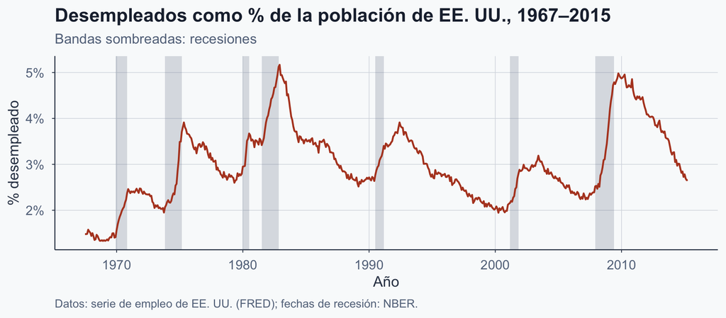

- El desempleo **subió durante o poco después** de cada recesión.
- **Por lo tanto**, la próxima recesión va a subir el desempleo
  - Una apuesta, no una garantía.

## El “probablemente” que falta

- Una inducción honesta debería matizar: *“probablemente”, “es probable”, “puede que”.*
- En el habla real, ese matiz es **lo primero que se cae**.
- Así, una **apuesta** se enuncia como si fuera una **garantía**.
- ¿Por qué? El público premia la **seguridad**, no los matices.

*“Cada tecnología del pasado acabó creando más empleos de los que destruyó.”*

Con exceso de confianza: **“La IA va a crear más empleos de los que destruya.”**

Honesto: **“La IA *probablemente* también cree empleos nuevos.”**

El movimiento honesto — y el más raro — es dejar el *“probablemente”*.

## El calentamiento, resuelto

> “…Una semana después se me quitó. **Por lo tanto**, la vitamina C me curó.”

Primera pregunta: ¿qué está **prometiendo** quien habla?

- No hay *tiene que*, no hay *necesariamente* — un diagnóstico causal a partir de un solo caso.
- Lo que promete es una **buena apuesta**, no una garantía: **inductivo**.
- Así que nos saltamos la validez y preguntamos por la **fuerza**.

## Hume: el problema de la inducción

> “El pan que comí antes me alimentó… pero ¿se sigue de ahí que otro pan deba alimentarme también en otro momento?”

> — *Investigación sobre el entendimiento humano* (1748), Sección IV, Parte II, ¶16
- La inducción va de casos observados a casos **no observados**.
- Supone que los patrones observados se sostienen en **casos parecidos que no hemos visto**.
- **La deducción no puede probar eso** — la naturaleza podría, concebiblemente, cambiar.
- **La experiencia tampoco** — esa defensa ya usa inducción *(un círculo)*.
- La ciencia **administra** esta incertidumbre; nunca la convierte en **prueba**.

## ¿Y esto para qué?

- La deducción **promete una garantía** — así que podemos revisar si la cumple.
- Esa revisión tiene nombre: **validez**.
- Es la palabra peor entendida de la lógica — la siguiente sección lo arregla.

# Parte 2: Validez y verdad

## La validez: el enlace

Un argumento deductivo es válido cuando:

**SI** las premisas son ciertas, la conclusión **tiene que** ser cierta.

- La validez evalúa el **razonamiento** que va de las premisas a la conclusión.
- No nos dice si las premisas son ciertas de hecho.
- La verdad se aplica a los enunciados; la **validez** se aplica a los argumentos.

**La prueba**: ¿pueden todas las premisas ser ciertas y la conclusión falsa?

- **No** → válido
- **Sí** → inválido

## Disparates válidos

| P1. | Todos los gatos son reptiles. |
| --- | --- |
| P2. | Todos los reptiles hablan francés. |
| C. | Todos los gatos hablan francés. |

- Cada renglón es **falso**.
- Y aun así, **si** P1 y P2 fueran ciertas, C tendría que serlo.
- La estructura en sí es **impecable**.
- **Argumento válido, todo falso.** Validez ≠ verdad.

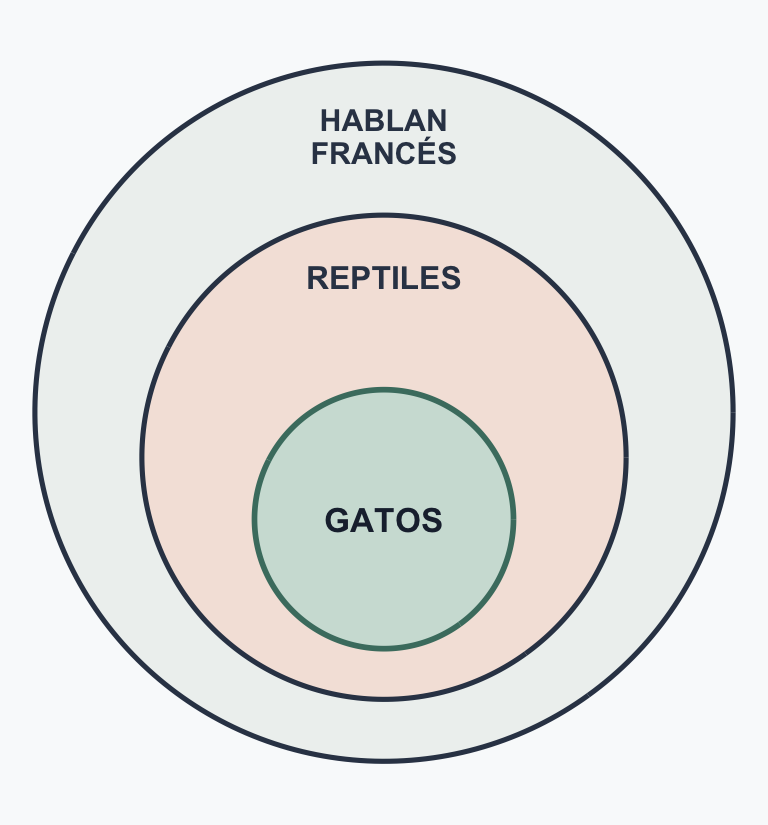

La forma: *Todo A es B; todo B es C; entonces todo A es C* — un **silogismo categórico**.

## La misma estructura, con contenido sensato

| P1. | Todos los poodles son perros. |
| --- | --- |
| P2. | Todos los perros son mamíferos. |
| C. | Todos los poodles son mamíferos. |

- Premisas **ciertas**, conclusión **cierta** — y **tenía** que seguirse.
- La misma estructura que los reptiles francófonos.
- **Otros hechos, la misma lógica.** La validez ignora el tema.

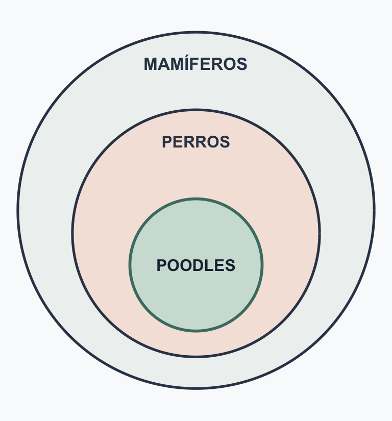

Cambien el contenido, conserven la forma — la validez no se mueve.

## La combinación prohibida

| P1. | Todos los gatos son mamíferos. |
| --- | --- |
| P2. | Todos los perros son mamíferos. |
| C. | Todos los gatos son perros. |

- Las dos premisas son **ciertas**. La conclusión es claramente **falsa**.
- Premisas ciertas **y** conclusión falsa — entonces: **inválido**.
- Compartir una categoría no es ser la misma cosa.

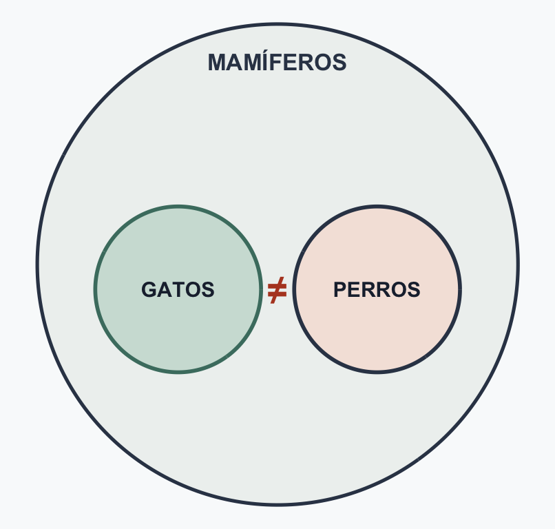

Este es el único patrón que un argumento válido **nunca** puede mostrar.

## Una conclusión de suerte

| P1. | Todos los gatos son mamíferos. |
| --- | --- |
| P2. | Todos los perros son mamíferos. |
| C. | Todas las ballenas son mamíferos. |

- Cada renglón es **cierto** — y aun así las premisas nunca mencionan ballenas.
- La conclusión es cierta **independientemente** de las premisas.

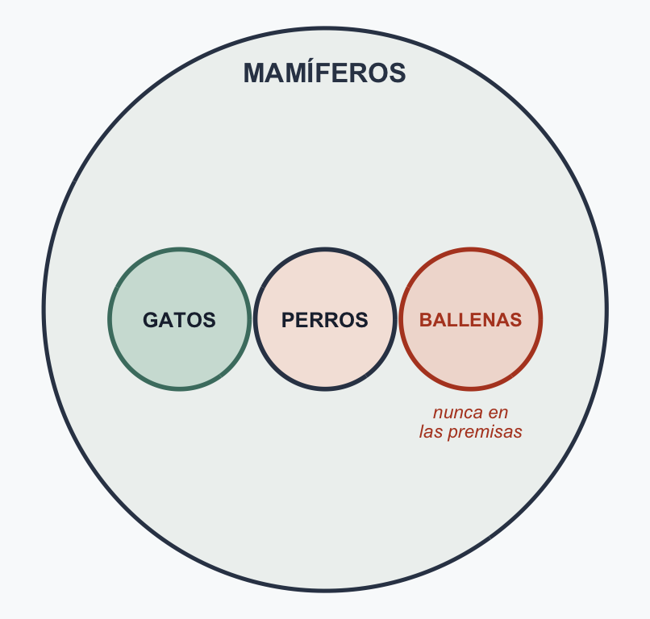

Una **conclusión cierta** nunca prueba que el razonamiento haya sido bueno.

## ¿Y esto para qué?

- La validez es un **control de calidad de la estructura**
  - ignora si las afirmaciones son ciertas por su cuenta.
- Pero argumentamos para **acertarle al mundo**.
- Necesitamos palabras para *válido + cierto* — y para las buenas apuestas.
- También necesitamos más vocabulario: **solidez, fuerza, cogencia**.

# Ejercicio 1: clasificar y juzgar

Para cada uno: **¿deductivo o inductivo?**

Luego — si es deductivo: *¿podrían las premisas ser ciertas y la conclusión falsa?*

- (no → **válido**)

Den una frase.

**1.** “Todos los que entraron al laboratorio firmaron. Leo entró al laboratorio. Así que Leo firmó.”

**2.** “Todos los cafés que abrieron en esta calle cerraron antes del año. Así que este nuevo también va a cerrar.”

**3.** “Si la batería está muerta, el coche no arranca. El coche no arranca. Así que la batería está muerta.”

## Ejercicio 1 — respuestas

**1.** *“Todos los que entraron al laboratorio firmaron. Leo entró al laboratorio. Así que Leo firmó.”*

- Garantía → **deductivo**, y se cumple → **VÁLIDO**
- Todos los que entraron firmaron, y Leo entró — no pudo no haber firmado.

**2.** *“Todos los cafés que abrieron en esta calle cerraron antes del año. Así que este nuevo también va a cerrar.”*

- Apuesta → **inductivo** → *no hay validez que probar*
- Una apuesta nunca prometió una garantía. Su calificación espera a la Parte 3.

**3.** *“Si la batería está muerta, el coche no arranca. El coche no arranca. Así que la batería está muerta.”*

- Garantía → **deductivo**, pero se rompe → **INVÁLIDO**
- Sin gasolina, la marcha descompuesta — una causa posible no es la única.

**La validez es una pregunta que solo se le hace a la deducción.**

## Por qué se rompe el 3

> *“Si la batería está muerta, el coche no arranca. El coche no arranca. Así que la batería está muerta.”*

**En forma estándar:**

| P1. | Si la batería está muerta, el coche no arranca. |
| --- | --- |
| P2. | El coche no arranca. |
| P3. *(oculta)* | Una batería muerta es lo **único** que detiene a un coche. |
| C. | La batería está muerta. |

- P1 y P2 son **ciertas** — pero solas no llegan a C.
- El argumento necesita **P3** en silencio. Y P3 es **falsa**.
- Tanque vacío: P1 y P2 ciertas, conclusión **falsa**.

**Digan la premisa oculta en voz alta y el argumento se muere.**

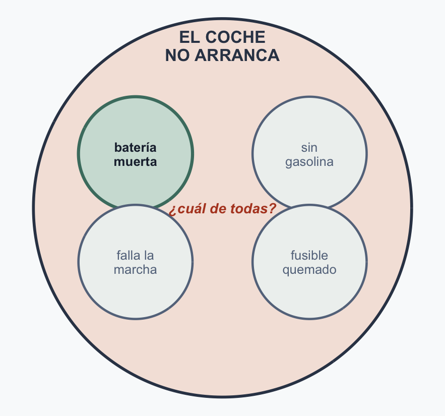

# Parte 3: Calificar argumentos

## Calificar argumentos: dos revisiones

Primero, identifiquen el **apoyo que promete** el argumento:

- **Deductivo** → evalúen la **validez**
- **Inductivo** → evalúen la **fuerza**

## Calificar argumentos: dos revisiones

### Revisión 1: ¿qué tan bueno es el enlace?

| Argumento deductivo | Argumento inductivo |
| --- | --- |
| ¿Podrían las premisas ser ciertas y la conclusión falsa? | ¿Qué tan probable hacen las premisas la conclusión? |
| **No → válido** | **Muy probable → fuerte** |
| **Sí → inválido** | **Poco probable → débil** |

## Calificar argumentos: dos revisiones

### Revisión 1: ¿qué tan bueno es el enlace?

| Argumento deductivo | Argumento inductivo |
| --- | --- |
| ¿Podrían las premisas ser ciertas y la conclusión falsa? | ¿Qué tan probable hacen las premisas la conclusión? |
| **No → válido** |  |

**P1: Si llueve, la calle se moja.**  
**P2: Llovió.**  
**C: Por lo tanto, la calle está mojada.**

**¿Por qué? La lluvia tiene que mojar la calle.**  
Las premisas no pueden ser ciertas con una conclusión falsa. **No → válido**

## Calificar argumentos: dos revisiones

### Revisión 1: ¿qué tan bueno es el enlace?

| Argumento deductivo | Argumento inductivo |
| --- | --- |
| ¿Podrían las premisas ser ciertas y la conclusión falsa? | ¿Qué tan probable hacen las premisas la conclusión? |
| **Sí → inválido** |  |

**P1: Si llueve, la calle se moja.**  
**P2: La calle está mojada.**  
**C: Por lo tanto, llovió.**

**¿Por qué? Mojada no quiere decir que llovió.**  
Pudo haberla mojado un aspersor. **Sí → inválido**

## Calificar argumentos: dos revisiones

### Revisión 1: ¿qué tan bueno es el enlace?

| Argumento deductivo | Argumento inductivo |
| --- | --- |
| ¿Podrían las premisas ser ciertas y la conclusión falsa? | ¿Qué tan probable hacen las premisas la conclusión? |
|  | **Muy probable → fuerte** |

**P1: Aquí ha llovido todos los días de este mes.**  
**C: Por lo tanto, mañana probablemente llueva aquí.**

**¿Por qué? Un mes es evidencia fuerte.**  
Muchas observaciones apoyan con fuerza la conclusión. **Muy probable → fuerte**

## Calificar argumentos: dos revisiones

### Revisión 1: ¿qué tan bueno es el enlace?

| Argumento deductivo | Argumento inductivo |
| --- | --- |
| ¿Podrían las premisas ser ciertas y la conclusión falsa? | ¿Qué tan probable hacen las premisas la conclusión? |
|  | **Poco probable → débil** |

**P1: Aquí llovió ayer.**  
**C: Por lo tanto, mañana probablemente llueva aquí.**

**¿Por qué? Un solo día casi no prueba nada.**  
Un único día apenas apoya la conclusión. **Poco probable → débil**

## Calificar argumentos: dos revisiones

### Revisión 2: ¿las premisas son ciertas de verdad?

| Argumentos deductivos | Argumentos inductivos |
| --- | --- |
| **Válido + premisas ciertas = SÓLIDO** | **Fuerte + premisas ciertas = COGENTE** |

Los argumentos **sólidos** dan una garantía deductiva basada en premisas ciertas.

Los argumentos **cogentes** dan un apoyo inductivo fuerte basado en premisas ciertas.

## Calificar argumentos: dos revisiones

### Revisión 2: ¿las premisas son ciertas de verdad?

| Argumentos deductivos | Argumentos inductivos |
| --- | --- |
| **Válido + premisas ciertas = SÓLIDO** |  |

Ejemplo:

**P1: Si llueve, la calle se moja.** **P2: Llovió.** **C: Por lo tanto, la calle está mojada.**

La conclusión **tiene que seguirse** de las premisas → **válido** Supongan que de hecho llovió → las dos premisas son **ciertas**

**Por lo tanto, el argumento es SÓLIDO.**

## Calificar argumentos: dos revisiones

### Revisión 2: ¿las premisas son ciertas de verdad?

| Argumentos deductivos | Argumentos inductivos |
| --- | --- |
|  | **Fuerte + premisas ciertas = COGENTE** |

Ejemplo:

**P1: Aquí ha llovido todos los días de este mes.**  
**C: Por lo tanto, mañana probablemente llueva aquí.**

La premisa hace la conclusión **muy probable** → **fuerte**  
Supongan que el mes de lluvia se confirma → la premisa es **cierta**

**Por lo tanto, el argumento es COGENTE.**

## Los cuatro pasos

Cualquier argumento que se encuentren, en el mismo orden:

1. **¿Deductivo o inductivo?** *(¿una garantía, o una buena apuesta?)*
2. **¿Se sostiene el enlace?** *(deductivo → ¿válido? · inductivo → ¿fuerte?)*
3. **¿Las premisas son ciertas?**
4. **Veredicto en una palabra:** *sólido · cogente · o ninguno.*

El paso 1 decide qué prueba corren los pasos 2 y 3.

## Para llevar: deducción

**En pocas palabras:**

- Buena lógica + premisas ciertas → **la conclusión tiene que ser cierta.**
- Buena lógica, una premisa falsa → **no está probado** *(puede ser cierto de todos modos).*
- Lógica rota → **no se sigue** *(puede ser cierto de todos modos).*

**Un mal argumento no vuelve falsa su conclusión — nada más no se la ha ganado.**

## Califiquen cada argumento

**¿Deductivo o inductivo? Luego el enlace — válido / inválido, o fuerte / débil.**  
**Y el veredicto: sólido · cogente · o ninguno.**

**1.** “Todos los cuadrados tienen cuatro lados. Esta figura es un cuadrado. Así que tiene cuatro lados.”

**2.** “Todos los perros son mamíferos. Este animal es mamífero. Así que es un perro.”

**3.** “Este paso de montaña ha cerrado por nieve todos los inviernos durante treinta años. Así que probablemente cierre este invierno también.”

**4.** “Dos de mis amigos se enfermaron después de comer ahí. Así que ese restaurante probablemente tiene mala higiene.”

## Califiquen cada argumento — respuestas

**1.** *“Todos los cuadrados tienen cuatro lados. Esta figura es un cuadrado. Así que tiene cuatro lados.”*

- Garantía → **deductivo** → **VÁLIDO**
- “Cuadrado” ya obliga a “cuatro lados”.
- ¿Premisas ciertas? *(suponiendo que se muestra la figura)* → **SÓLIDO**

**2.** *“Todos los perros son mamíferos. Este animal es mamífero. Así que es un perro.”*

- Garantía → **deductivo** → **INVÁLIDO**
- Un gato también es mamífero — compartir categoría no es ser la misma cosa.
- Ser inválido ya lo resuelve → **NO SÓLIDO**

**3.** *“Este paso de montaña ha cerrado por nieve todos los inviernos durante treinta años. Así que probablemente cierre este invierno también.”*

- Apuesta → **inductivo** → **FUERTE**
- Treinta inviernos, el mismo paso, la misma causa.
- ¿Premisas ciertas? *(suponiendo registros oficiales)* → **COGENTE**

**4.** *“Dos de mis amigos se enfermaron después de comer ahí. Así que ese restaurante probablemente tiene mala higiene.”*

- Apuesta → **inductivo** → **DÉBIL**
- Dos casos — ¿de cuántos comensales?
- Ser débil ya lo resuelve → **NO COGENTE**

## Para llevar: inducción

**En pocas palabras:**

- Apoyo fuerte + premisas ciertas → **razonable aceptarlo** *(sigue siendo revisable).*
- Patrón fuerte, una premisa falsa → **no está establecido** *(puede ser cierto de todos modos).*
- Muy poca evidencia → **no alcanza para aceptarlo** *(puede ser cierto de todos modos).*

**Un argumento débil no vuelve falsa su conclusión — nada más no se la ha ganado.**

## Dos carriles que nunca se cruzan

**“Válido” es palabra de deducción. “Fuerte” es palabra de inducción.** Nunca las cambien.

```
%%{init: {"flowchart": {"useMaxWidth": true, "htmlLabels": false, "nodeSpacing": 22, "rankSpacing": 30, "padding": 20}, "themeVariables": {"fontSize": "14px", "edgeLabelBackground": "#ffffff"}}}%%
flowchart TB
  A["UN ARGUMENTO<br/>¿qué promete?"]
  A -->|"una GARANTÍA"| D["DEDUCTIVO"]
  A -->|"una BUENA APUESTA"| I["INDUCTIVO"]
  D --> D1["Paso 2: el enlace<br/>VÁLIDO o INVÁLIDO"]
  I --> I1["Paso 2: el enlace<br/>FUERTE o DÉBIL"]
  D1 --> D2["Paso 3: ¿premisas ciertas?<br/>entonces SÓLIDO"]
  I1 --> I2["Paso 3: ¿premisas ciertas?<br/>entonces COGENTE"]
  D2 --> D3["conclusión<br/>TIENE que ser cierta"]
  I2 --> I3["conclusión<br/>PROBABLEMENTE cierta"]
  style A fill:#1e293b,color:#f9fafb,stroke:#1e293b
  style D fill:#4a7c6f,color:#f9fafb,stroke:#4a7c6f
  style I fill:#b44527,color:#f9fafb,stroke:#b44527
  style D1 fill:#cfe0d8,color:#1e293b,stroke:#4a7c6f
  style D2 fill:#cfe0d8,color:#1e293b,stroke:#4a7c6f
  style D3 fill:#cfe0d8,color:#1e293b,stroke:#4a7c6f
  style I1 fill:#f4e4dc,color:#1e293b,stroke:#b44527
  style I2 fill:#f4e4dc,color:#1e293b,stroke:#b44527
  style I3 fill:#f4e4dc,color:#1e293b,stroke:#b44527
```

## Con qué se van

1. **Dos familias**: una garantía (deducción) o una buena apuesta (inducción).
2. **Una celda prohibida**: válido + premisas ciertas + conclusión falsa.
3. **Cuatro calificaciones**: válido, sólido; fuerte, cogente.
4. **Cuatro pasos** para calificar cualquier argumento que se encuentren.
5. **Un hábito**: cuando el apoyo es débil, **prometan menos**.

## Referencias

- Hume, D. (2007). *An enquiry concerning human understanding* (P. Millican, Ed.). Oxford University Press. (Obra original publicada en 1748; Sección IV, Parte II, ¶16 / SBN 33–34.)
- National Bureau of Economic Research. (2023). *US business cycle expansions and contractions*. https://www.nber.org/research/data/us-business-cycle-expansions-and-contractions